# Final EFA Attitude

Author

firdaus

This analysis is for Attitude section, with selection threshold higher (FL =>0.5), communality => 0.5

# 1 Preliminaries

## 1.1 Load libraries

```r
library(foreign)  # for importing SPSS data
library(psych)  # for psychometrics
library(lattice)  # easy to plot multivariate plots
library(readxl)
library(dplyr)
```

## 1.2 Load dataset

```r
data1= read_xlsx("EFA_Attitude_V1.xlsx")
```

```r
names(data1)
```

```
 [1] "A1"  "A2"  "A3"  "A4"  "A5"  "A6"  "A7"  "A8"  "A9"  "A10" "A11" "A12"
[13] "A13" "A14" "A15" "A16" "A17" "A18" "A19" "A20" "A21" "A22" "A23" "A24"
[25] "A25" "A26" "A27" "A28" "A29" "A30"
```

```r
head(data1)
```

```
# A tibble: 6 × 30
  A1     A2    A3    A4    A5    A6    A7    A8    A9    A10   A11   A12   A13
  <chr>  <chr> <chr> <chr> <chr> <chr> <chr> <chr> <chr> <chr> <chr> <chr> <chr>
1 Sanga… Sang… Setu… Sang… Sang… Sang… Tida… Tida… Tida… Sang… Sang… Tida… Tida…
2 Sanga… Sang… Sang… Sang… Sang… Sang… Tida… Tida… Tida… Sang… Sang… Tida… Tida…
3 Sanga… Sang… Sang… Sang… Sang… Sang… Tida… Tida… Tida… Sang… Sang… Sang… Tida…
4 Sanga… Sang… Sang… Sang… Sang… Sang… Tida… Tida… Tida… Tida… Tida… Tida… Tida…
5 Sanga… Sang… Sang… Sang… Sang… Sang… Tida… Sang… Tida… Tida… Sang… Sang… Tida…
6 Sanga… Sang… Sang… Sang… Sang… Sang… Sang… Sang… Sang… Sang… Sang… Sang… Sang…
# ℹ 17 more variables: A14 <chr>, A15 <chr>, A16 <chr>, A17 <chr>, A18 <chr>,
#   A19 <chr>, A20 <chr>, A21 <chr>, A22 <chr>, A23 <chr>, A24 <chr>,
#   A25 <chr>, A26 <chr>, A27 <chr>, A28 <chr>, A29 <chr>, A30 <chr>
```

## 1.3 Coding the answers

```r
# Define mapping functions
likert_map <- function(x) {
  recode <- c(
    "Sangat tidak setuju" = 1,
    "Tidak setuju"        = 2,
    "Tidak pasti"         = 3,
    "Setuju"              = 4,
    "Sangat setuju"       = 5
  )
  recode[match(tolower(x), tolower(names(recode)))]
}

likert_reverse <- function(x) {
  recode <- c(
    "Sangat tidak setuju" = 5,
    "Tidak setuju"        = 4,
    "Tidak pasti"         = 3,
    "Setuju"              = 2,
    "Sangat setuju"       = 1
  )
  recode[match(tolower(x), tolower(names(recode)))]
}

# List of reverse-coded items
reverse_items <- c("A7","A8","A9","A10","A11","A12","A13",
                   "A20","A21","A23","A25","A27","A29")

# Apply transformation from data1 -> data2
data2 <- data1

for (col in names(data2)) {
  if (col %in% reverse_items) {
    data2[[col]] <- likert_reverse(data2[[col]])
  } else {
    data2[[col]] <- likert_map(data2[[col]])
  }
}

# Convert all to numeric
data2 <- as.data.frame(lapply(data2, as.numeric))
```

```r
head(data2)
```

```
  A1 A2 A3 A4 A5 A6 A7 A8 A9 A10 A11 A12 A13 A14 A15 A16 A17 A18 A19 A20 A21
1  5  5  4  5  5  5  4  4  4   5   5   4   4   5   5   5   5   5   5   1   1
2  5  5  5  5  5  5  3  3  3   5   5   4   4   5   5   5   5   5   5   1   1
3  5  5  5  5  5  5  4  4  4   5   5   5   4   5   5   5   5   5   5   3   3
4  5  5  5  5  5  5  4  4  4   4   4   4   4   4   4   4   4   4   4   2   3
5  5  5  5  5  5  5  3  1  3   4   5   1   4   5   5   5   5   5   5   1   2
6  5  5  5  5  5  5  5  5  5   5   5   5   5   5   5   5   5   5   5   5   5
  A22 A23 A24 A25 A26 A27 A28 A29 A30
1   5   5   5   5   5   3   5   4   5
2   5   5   5   5   5   5   4   4   5
3   5   5   4   2   4   2   4   2   4
4   4   4   3   2   3   4   4   4   4
5   5   5   5   1   5   1   5   2   5
6   5   5   4   1   4   2   5   1   5
```

```r
str(data2)
```

```
'data.frame':   204 obs. of  30 variables:
 $ A1 : num  5 5 5 5 5 5 4 5 5 5 ...
 $ A2 : num  5 5 5 5 5 5 4 5 5 5 ...
 $ A3 : num  4 5 5 5 5 5 4 5 5 5 ...
 $ A4 : num  5 5 5 5 5 5 4 5 5 5 ...
 $ A5 : num  5 5 5 5 5 5 4 5 5 5 ...
 $ A6 : num  5 5 5 5 5 5 4 5 5 5 ...
 $ A7 : num  4 3 4 4 3 5 3 4 4 5 ...
 $ A8 : num  4 3 4 4 1 5 3 4 4 5 ...
 $ A9 : num  4 3 4 4 3 5 3 4 3 5 ...
 $ A10: num  5 5 5 4 4 5 5 4 5 1 ...
 $ A11: num  5 5 5 4 5 5 5 4 5 1 ...
 $ A12: num  4 4 5 4 1 5 3 3 5 2 ...
 $ A13: num  4 4 4 4 4 5 4 4 4 1 ...
 $ A14: num  5 5 5 4 5 5 5 5 4 5 ...
```

[output cut: 16 more lines]

# 2 Exploratory factor analysis

## 2.1 Descriptive statistics

```r
describe(data2)
```

```
    vars   n mean   sd median trimmed  mad min max range  skew kurtosis   se
A1     1 204 4.43 0.84      5    4.59 0.00   1   5     4 -2.11     5.66 0.06
A2     2 204 4.32 0.87      5    4.48 0.00   1   5     4 -1.64     3.33 0.06
A3     3 204 4.49 0.82      5    4.64 0.00   1   5     4 -2.38     7.09 0.06
A4     4 204 4.45 0.87      5    4.62 0.00   1   5     4 -2.29     6.09 0.06
A5     5 204 4.44 0.87      5    4.60 0.00   1   5     4 -2.25     5.97 0.06
A6     6 204 4.37 0.90      5    4.55 0.00   1   5     4 -1.91     4.25 0.06
A7     7 204 3.25 1.04      3    3.26 1.48   1   5     4 -0.23    -0.62 0.07
A8     8 204 3.31 1.00      3    3.34 1.48   1   5     4 -0.39    -0.33 0.07
A9     9 204 3.48 0.95      3    3.49 1.48   1   5     4 -0.17    -0.37 0.07
A10   10 204 4.11 0.97      4    4.27 1.48   1   5     4 -1.16     1.01 0.07
A11   11 204 4.23 0.92      4    4.39 1.48   1   5     4 -1.33     1.58 0.06
A12   12 204 3.79 1.05      4    3.89 1.48   1   5     4 -0.79    -0.14 0.07
A13   13 204 3.84 1.02      4    3.94 1.48   1   5     4 -0.80    -0.13 0.07
A14   14 204 4.41 0.71      5    4.51 0.00   1   5     4 -1.51     3.94 0.05
A15   15 204 4.48 0.65      5    4.55 0.00   1   5     4 -1.40     3.60 0.05
A16   16 204 4.50 0.59      5    4.55 0.00   1   5     4 -1.30     4.37 0.04
A17   17 204 4.49 0.62      5    4.55 0.00   1   5     4 -1.28     3.45 0.04
A18   18 204 4.50 0.63      5    4.57 0.00   1   5     4 -1.32     3.36 0.04
A19   19 204 4.48 0.65      5    4.55 0.00   1   5     4 -1.40     3.60 0.05
A20   20 204 2.67 1.21      2    2.62 1.48   1   5     4  0.41    -0.98 0.08
A21   21 204 3.39 1.17      4    3.45 1.48   1   5     4 -0.45    -0.80 0.08
A22   22 204 4.43 0.61      4    4.46 0.74   1   5     4 -1.20     4.11 0.04
A23   23 204 4.45 0.93      5    4.67 0.00   1   5     4 -2.02     3.82 0.07
A24   24 204 3.74 0.84      4    3.78 1.48   1   5     4 -0.43    -0.08 0.06
A25   25 204 2.53 1.09      2    2.46 0.00   1   5     4  0.75    -0.34 0.08
A26   26 204 3.82 0.89      4    3.87 1.48   1   5     4 -0.31    -0.51 0.06
A27   27 204 2.83 1.16      3    2.80 1.48   1   5     4  0.31    -0.92 0.08
A28   28 204 4.28 0.68      4    4.37 0.00   1   5     4 -0.89     1.89 0.05
A29   29 204 2.98 1.18      3    2.96 1.48   1   5     4  0.09    -1.11 0.08
A30   30 204 4.24 0.74      4    4.32 1.48   1   5     4 -0.77     0.74 0.05
```

## 2.2 % of response to options per item

```r
response.frequencies(data2)
```

```
              1           2          3         4          5 miss
A1  0.029411765 0.000000000 0.05392157 0.3480392 0.56862745    0
A2  0.024509804 0.009803922 0.09313725 0.3627451 0.50980392    0
A3  0.029411765 0.000000000 0.03431373 0.3235294 0.61274510    0
A4  0.034313725 0.004901961 0.03431373 0.3284314 0.59803922    0
A5  0.034313725 0.004901961 0.03431373 0.3431373 0.58333333    0
A6  0.034313725 0.000000000 0.08333333 0.3235294 0.55882353    0
A7  0.049019608 0.196078431 0.30882353 0.3431373 0.10294118    0
A8  0.049019608 0.151960784 0.32843137 0.3774510 0.09313725    0
A9  0.019607843 0.117647059 0.37745098 0.3382353 0.14705882    0
A10 0.019607843 0.063725490 0.10784314 0.4019608 0.40686275    0
A11 0.014705882 0.053921569 0.08333333 0.3823529 0.46568627    0
A12 0.024509804 0.137254902 0.11764706 0.4656863 0.25490196    0
A13 0.014705882 0.137254902 0.10784314 0.4754902 0.26470588    0
A14 0.009803922 0.004901961 0.05882353 0.4166667 0.50980392    0
A15 0.004901961 0.004901961 0.03921569 0.4068627 0.54411765    0
A16 0.004901961 0.000000000 0.01960784 0.4362745 0.53921569    0
A17 0.004901961 0.000000000 0.03921569 0.4166667 0.53921569    0
A18 0.004901961 0.000000000 0.04411765 0.3970588 0.55392157    0
A19 0.004901961 0.004901961 0.03921569 0.4068627 0.54411765    0
A20 0.147058824 0.421568627 0.12254902 0.2303922 0.07843137    0
A21 0.068627451 0.196078431 0.17156863 0.4068627 0.15686275    0
A22 0.004901961 0.004901961 0.01960784 0.5000000 0.47058824    0
A23 0.024509804 0.039215686 0.04411765 0.2450980 0.64705882    0
A24 0.004901961 0.073529412 0.26470588 0.4901961 0.16666667    0
A25 0.117647059 0.519607843 0.13725490 0.1617647 0.06372549    0
A26 0.004901961 0.058823529 0.29411765 0.3921569 0.25000000    0
A27 0.098039216 0.377450980 0.21078431 0.2205882 0.09313725    0
A28 0.004901961 0.004901961 0.08333333 0.5147059 0.39215686    0
A29 0.088235294 0.338235294 0.18137255 0.2892157 0.10294118    0
A30 0.004901961 0.004901961 0.13725490 0.4509804 0.40196078    0
```

## 2.3 Normality of data

### 2.3.1 Univariate normality

#### 2.3.1.1 Histogram

```r
cat(names(data2), sep = " + ")
```

```
A1 + A2 + A3 + A4 + A5 + A6 + A7 + A8 + A9 + A10 + A11 + A12 + A13 + A14 + A15 + A16 + A17 + A18 + A19 + A20 + A21 + A22 + A23 + A24 + A25 + A26 + A27 + A28 + A29 + A30
```

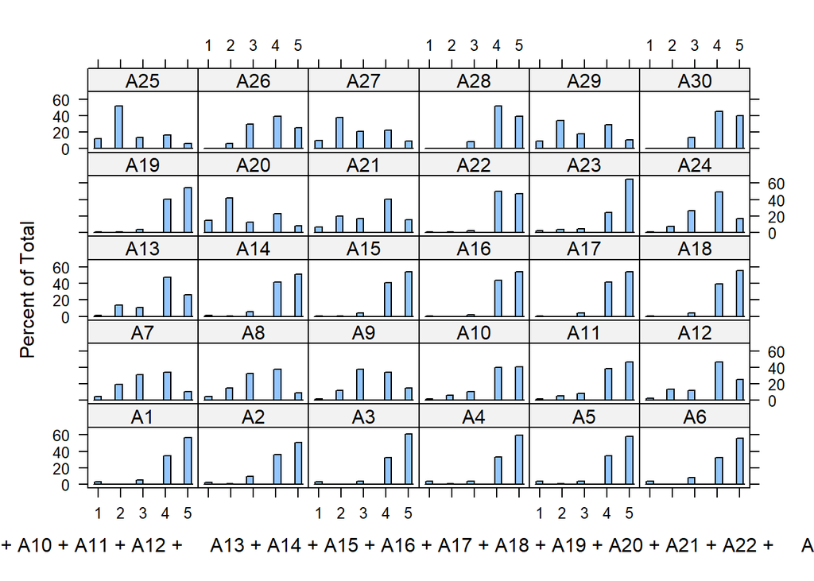

```r
histogram(~ A1 + A2 + A3 + A4 + A5 + A6 + A7 + A8 + A9 + A10 + A11 + A12 + A13 + A14 + A15 + A16 + A17 + A18 + A19 + A20 + A21 + A22 + A23 + A24 + A25 + A26 + A27 + A28 + A29 + A30,
          data = data2)
```

By eye-balling method, most of item answers were not normality distributed

#### 2.3.1.2 Shapiro Wilk’s test

```r
mapply(shapiro.test, data2)
```

```
          A1                            A2
statistic 0.6562623                     0.7245687
p.value   4.196902e-20                  4.065506e-18
method    "Shapiro-Wilk normality test" "Shapiro-Wilk normality test"
data.name "dots[[1L]][[1L]]"            "dots[[1L]][[2L]]"
          A3                            A4
statistic 0.6134937                     0.6234966
p.value   3.359928e-21                  5.946301e-21
method    "Shapiro-Wilk normality test" "Shapiro-Wilk normality test"
data.name "dots[[1L]][[3L]]"            "dots[[1L]][[4L]]"
          A5                            A6
statistic 0.6310143                     0.6815302
p.value   9.2019e-21                    2.089599e-19
method    "Shapiro-Wilk normality test" "Shapiro-Wilk normality test"
data.name "dots[[1L]][[5L]]"            "dots[[1L]][[6L]]"
          A7                            A8
statistic 0.9064007                     0.8964053
p.value   4.922676e-10                  1.107925e-10
method    "Shapiro-Wilk normality test" "Shapiro-Wilk normality test"
data.name "dots[[1L]][[7L]]"            "dots[[1L]][[8L]]"
          A9                            A10
statistic 0.8955108                     0.7949545
p.value   9.740029e-11                  1.206302e-15
method    "Shapiro-Wilk normality test" "Shapiro-Wilk normality test"
data.name "dots[[1L]][[9L]]"            "dots[[1L]][[10L]]"
          A11                           A12
statistic 0.762581                      0.839228
p.value   7.551849e-17                  9.346786e-14
method    "Shapiro-Wilk normality test" "Shapiro-Wilk normality test"
data.name "dots[[1L]][[11L]]"           "dots[[1L]][[12L]]"
          A13                           A14
statistic 0.8308263                     0.7154307
p.value   3.856039e-14                  2.106276e-18
method    "Shapiro-Wilk normality test" "Shapiro-Wilk normality test"
data.name "dots[[1L]][[13L]]"           "dots[[1L]][[14L]]"
          A15                           A16
statistic 0.6981262                     0.6722498
p.value   6.321289e-19                  1.146443e-19
method    "Shapiro-Wilk normality test" "Shapiro-Wilk normality test"
data.name "dots[[1L]][[15L]]"           "dots[[1L]][[16L]]"
```

[output cut: 20 more lines]

```
          A25                           A26
statistic 0.8358195                     0.8702078
p.value   6.501394e-14                  3.328605e-12
method    "Shapiro-Wilk normality test" "Shapiro-Wilk normality test"
data.name "dots[[1L]][[25L]]"           "dots[[1L]][[26L]]"
          A27                           A28
statistic 0.8935002                     0.7641312
p.value   7.310329e-11                  8.567832e-17
method    "Shapiro-Wilk normality test" "Shapiro-Wilk normality test"
data.name "dots[[1L]][[27L]]"           "dots[[1L]][[28L]]"
          A29                           A30
statistic 0.8940464                     0.7937877
p.value   7.900235e-11                  1.085883e-15
method    "Shapiro-Wilk normality test" "Shapiro-Wilk normality test"
data.name "dots[[1L]][[29L]]"           "dots[[1L]][[30L]]"
```

All item were not normally distributed

#### 2.3.1.3 Multivariate normality

To say the data are multivariate normal:

- *z*-kurtosis < 5 ([Bentler, 2006](https://wnarifin.github.io/lecture/mstat/efa_medstat_practical.html#ref-bentler2006)) and the *P*-value should be ≥ 0.05
- The plot should also form a straight line ([Arifin, 2015](https://wnarifin.github.io/lecture/mstat/efa_medstat_practical.html#ref-arifin2015))

Run Mardia’s multivariate normality test,

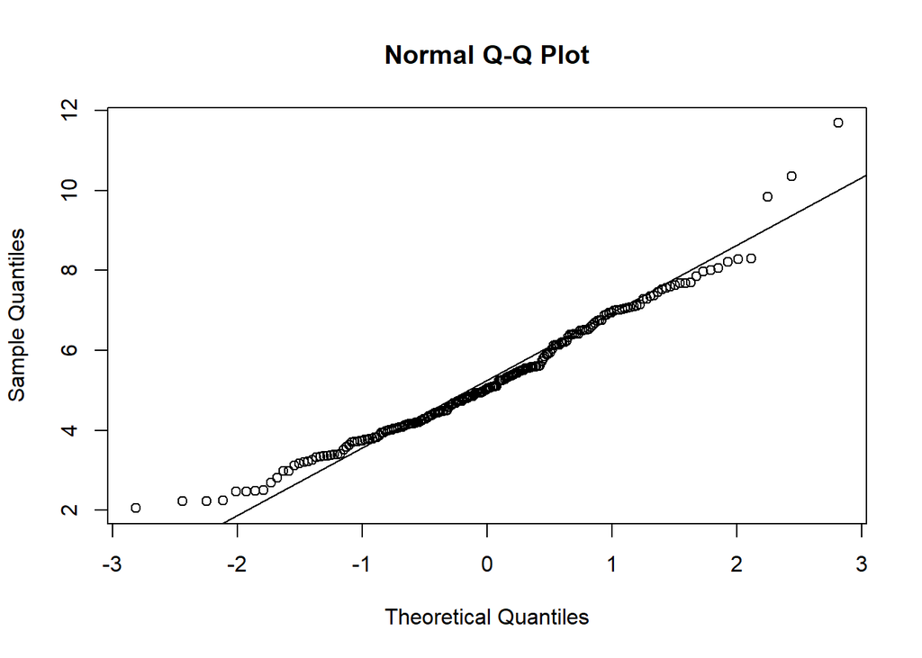

```
Call: mardia(x = data2)

Mardia tests of multivariate skew and kurtosis
Use describe(x) the to get univariate tests
n.obs = 204   num.vars =  30
b1p =  363.59   skew =  12362.08  with probability  <=  0
 small sample skew =  12555.73  with probability <=  0
b2p =  1234.54   kurtosis =  44.74  with probability <=  0
```

```r
mardia(data2)
```

Kurtosis < 0.001, multivariate not normally distributed

## 2.4 Step 1

### 2.4.1 Check suitability of data for analysis

#### 2.4.1.1 Kaiser-Meyer-Olkin (KMO) Measure of Sampling Adequacy (MSA)

```r
KMO(data2)
```

```
Kaiser-Meyer-Olkin factor adequacy
Call: KMO(r = data2)
Overall MSA =  0.88
MSA for each item =
  A1   A2   A3   A4   A5   A6   A7   A8   A9  A10  A11  A12  A13  A14  A15  A16
0.92 0.91 0.94 0.93 0.89 0.90 0.78 0.75 0.78 0.80 0.81 0.81 0.78 0.92 0.92 0.90
 A17  A18  A19  A20  A21  A22  A23  A24  A25  A26  A27  A28  A29  A30
0.89 0.87 0.92 0.62 0.56 0.94 0.93 0.84 0.75 0.90 0.72 0.94 0.83 0.93
```

Our MSA is meritorious

#### 2.4.1.2 Bartlet’s test of sphericity

```r
cortest.bartlett(data2)
```

```
R was not square, finding R from data
```

```
$chisq
[1] 5608.932

$p.value
[1] 0

$df
[1] 435
```

*P*-value < 0.05, significant. Items are correlated and worthwhile for factor analysis

### 2.4.2 Determine the number of factors

#### 2.4.2.1 Eigen value & scree plot

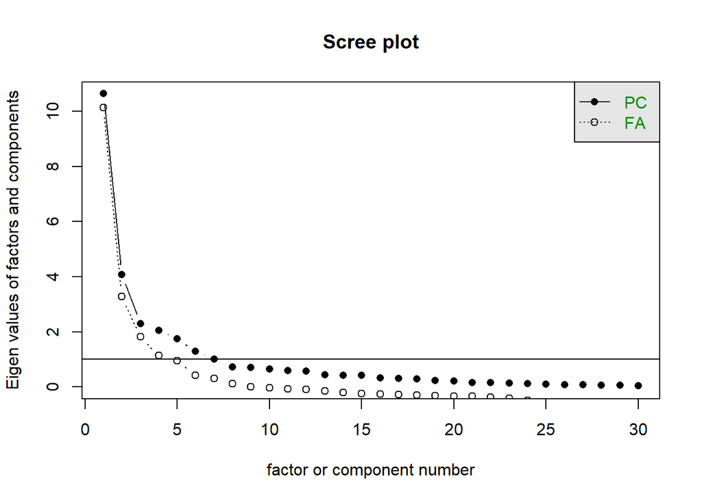

```r
scree = scree(data2)
```

```r
print(scree)
```

```
Scree of eigen values
Call: NULL
Eigen values of factors  [1] 10.13  3.27  1.82  1.13  0.96  0.42  0.31  0.12  0.00 -0.04 -0.07 -0.09
[13] -0.14 -0.20 -0.24 -0.26 -0.28 -0.30 -0.32 -0.33 -0.35 -0.38 -0.41 -0.50
[25] -0.60 -0.62 -0.68 -0.69 -0.73 -0.81
Eigen values of Principal Components [1] 10.64  4.08  2.30  2.05  1.74  1.30  1.01  0.73  0.70  0.65  0.60  0.57
[13]  0.45  0.43  0.41  0.33  0.31  0.28  0.23  0.21  0.16  0.16  0.14  0.11
[25]  0.10  0.08  0.07  0.06  0.05  0.05
```

Eigen values of factors > 1 = 4

Thus, based on our judgement on the scree plot and eigenvalues (of factor analysis), the suitable number of factors = 4 or 5

#### 2.4.2.2 Parallel analysis

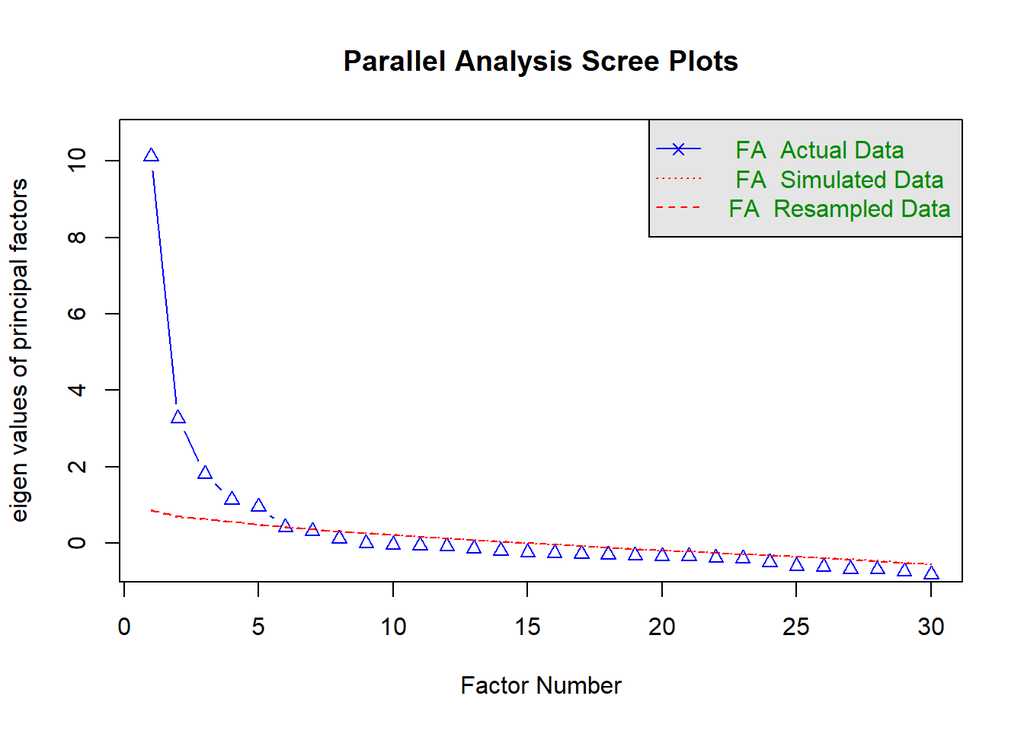

```
Parallel analysis suggests that the number of factors =  5  and the number of components =  NA
```

```r
parallel = fa.parallel(data2, fm = "pa", fa = "fa")
```

There are five dots above the dashed lines. This is suggestive of 5 factors

#### 2.4.2.3 Very simple structure (VSS) criterion & Velicer’s minimum average partial (MAP) criterion)

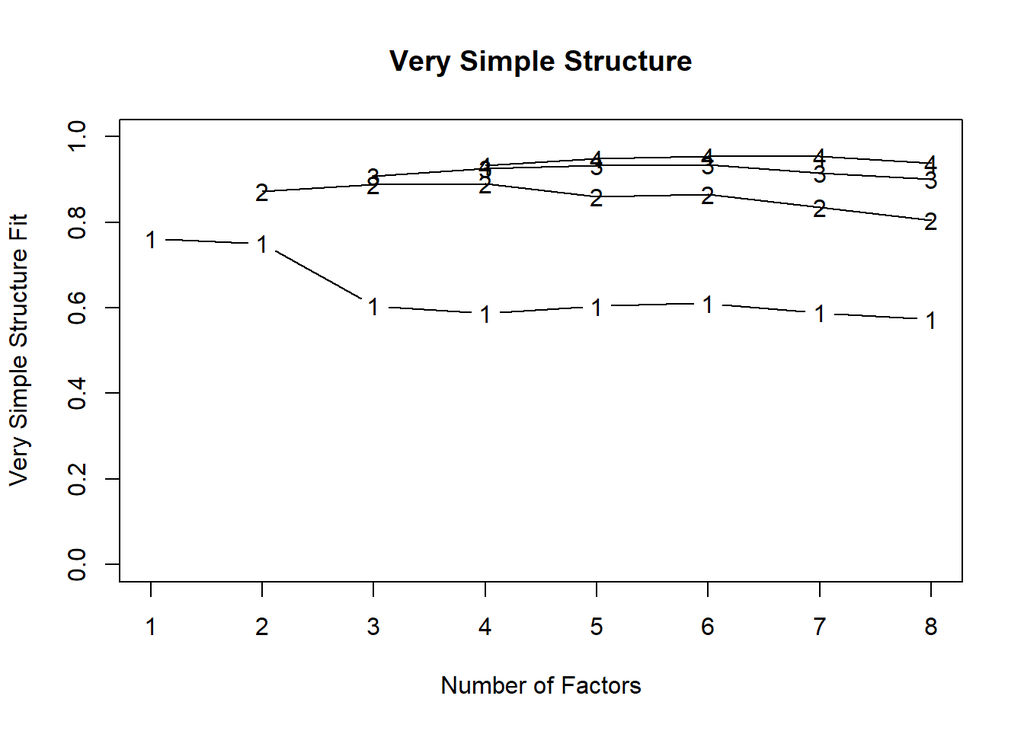

```
Very Simple Structure
Call: vss(x = data2)
VSS complexity 1 achieves a maximimum of 0.76  with  1  factors
VSS complexity 2 achieves a maximimum of 0.89  with  4  factors

The Velicer MAP achieves a minimum of 0.03  with  6  factors
BIC achieves a minimum of  -581.56  with  8  factors
Sample Size adjusted BIC achieves a minimum of  124.98  with  8  factors

Statistics by number of factors
  vss1 vss2   map dof chisq     prob sqresid  fit RMSEA  BIC SABIC complex
1 0.76 0.00 0.064 405  3421  0.0e+00    35.4 0.76 0.191 1267  2550     1.0
2 0.75 0.87 0.057 376  2725  0.0e+00    19.0 0.87 0.175  726  1917     1.2
3 0.61 0.89 0.033 348  1761 3.2e-187    13.7 0.91 0.141  -89  1013     1.4
4 0.59 0.89 0.033 321  1454 1.8e-143     9.9 0.93 0.131 -253   764     1.4
5 0.60 0.86 0.030 295  1131  3.8e-98     6.8 0.95 0.118 -438   497     1.5
6 0.61 0.87 0.027 270   954  4.0e-77     5.0 0.97 0.111 -482   374     1.5
7 0.59 0.83 0.027 246   844  1.5e-66     4.1 0.97 0.109 -464   315     1.6
8 0.57 0.80 0.031 223   604  6.4e-37     3.6 0.98 0.091 -582   125     1.6
  eChisq  SRMR eCRMS  eBIC
1   4209 0.154 0.160  2056
2   1859 0.102 0.110  -140
3   1074 0.078 0.087  -777
4    670 0.061 0.072 -1037
5    329 0.043 0.052 -1240
6    181 0.032 0.041 -1255
7    120 0.026 0.035 -1188
8     74 0.020 0.029 -1111
```

```r
vss(data2)
```

The suggestive factors are from 1 - 6 factors

## 2.5 Step 2

### 2.5.1 Run EFA 5 factors

After running EFA 5 factors, we have it not suitable due to presence of only 2 items in PA 5

**Summary EFA 5 Factors**

**PA1** : A1, A2, A3, A4, A5, A6

**PA2** : A7, A8, A9

**PA3** : A14,A15,A16,A17,A18,A19,A22

**PA4** : A10, A11, A12, A13

**PA5** : A27, A29

### 2.5.2 **Run EFA 4 factors**

**Summary EFA 4 Factors**

**PA1** : A1, A2, A3, A4, A5, A6

**PA2** : A7, A8, A9

**PA3** : A14, A15, A16, A17, A18, A19, A22

**PA4** : A10, A11, A12, A13

We chose 3 Factors because overall Factor Loading for each item is higher in EFA 3 factors compared to EFA 4 factors

### 2.5.3 Run EFA 3 factors

Cut off factor loading based on Hair (2019) ( => 0.5 practically significant structure)

```r
fa = fa(data2, nfactors = 3, fm = "pa", rotate = "oblimin")
print(fa, cut = .5, digits = 3)  # cut = .3 to view only FLs > 0.3
```

```
Factor Analysis using method =  pa
Call: fa(r = data2, nfactors = 3, rotate = "oblimin", fm = "pa")
Standardized loadings (pattern matrix) based upon correlation matrix
       PA1    PA3    PA2     h2     u2  com
A1          0.882        0.8450 0.1550 1.01
A2          0.859        0.7824 0.2176 1.02
A3          0.951        0.9069 0.0931 1.00
A4          0.924        0.8333 0.1667 1.01
A5          0.951        0.8976 0.1024 1.00
A6          0.916        0.8047 0.1953 1.02
A7                 0.772 0.5630 0.4370 1.04
A8                 0.737 0.5087 0.4913 1.04
A9                 0.722 0.5020 0.4980 1.03
A10                0.618 0.5575 0.4425 1.30
A11                0.608 0.5746 0.4254 1.50
A12                0.540 0.4220 0.5780 1.34
A13                      0.3537 0.6463 1.66
A14  0.756               0.5268 0.4732 1.03
A15  0.894               0.7797 0.2203 1.00
A16  0.909               0.8214 0.1786 1.01
A17  0.887               0.7900 0.2100 1.00
A18  0.841               0.7427 0.2573 1.00
A19  0.777               0.6423 0.3577 1.01
A20                      0.0961 0.9039 1.53
A21                      0.0660 0.9340 1.16
A22  0.704               0.5711 0.4289 1.02
A23                      0.2123 0.7877 1.68
A24                      0.1459 0.8541 2.27
A25                      0.2005 0.7995 1.13
A26                      0.3227 0.6773 1.89
A27                0.563 0.2953 0.7047 1.05
A28  0.620               0.4543 0.5457 1.04
A29                0.524 0.2667 0.7333 1.01
A30                      0.4383 0.5617 1.49

                        PA1   PA3   PA2
SS loadings           6.369 5.327 4.228
Proportion Var        0.212 0.178 0.141
Cumulative Var        0.212 0.390 0.531
Proportion Explained  0.400 0.335 0.266
```

[output cut: 14 more lines]

```
The root mean square of the residuals (RMSR) is  0.078
The df corrected root mean square of the residuals is  0.087

The harmonic n.obs is  204 with the empirical chi square  1073.84  with prob <  4.94e-75
The total n.obs was  204  with Likelihood Chi Square =  1761.402  with prob <  3.16e-187

Tucker Lewis Index of factoring reliability =  0.6546
RMSEA index =  0.141  and the 90 % confidence intervals are  0.1349 0.148
BIC =  -89.304
Fit based upon off diagonal values = 0.955
Measures of factor score adequacy
                                                    PA1   PA3   PA2
Correlation of (regression) scores with factors   0.978 0.988 0.941
Multiple R square of scores with factors          0.957 0.975 0.886
Minimum correlation of possible factor scores     0.915 0.950 0.772
```

**Poor items identified**

A13 (poor FL and communality)

A20 (poor FL and communality)

A21 (poor FL and communality)

A23 (poor FL and communality)

A24 (poor FL and communality)

A25 (poor FL and communality)

A26 (poor FL and communality)

A30 (poor FL and communality)

A12 (poor communality)

A27 (poor communality)

A28 (poor communality)

No factor with cross-loading

Factor correlation is all <0.85

```
      PA1   PA3   PA2
PA1 1.000 0.593 0.281
PA3 0.593 1.000 0.185
```

## 2.6 Step 3

### 2.6.1 Item A13 Removal

```r
fa1 = fa(subset(data2, select = -A13), nfactors = 3, fm = "pa", rotate = "oblimin")
print(fa1, cut = .5, digits = 3)
```

```
Factor Analysis using method =  pa
Call: fa(r = subset(data2, select = -A13), nfactors = 3, rotate = "oblimin",
    fm = "pa")
Standardized loadings (pattern matrix) based upon correlation matrix
       PA1    PA3    PA2     h2     u2  com
A1          0.881        0.8443 0.1557 1.01
A2          0.862        0.7835 0.2165 1.02
A3          0.951        0.9059 0.0941 1.00
A4          0.922        0.8303 0.1697 1.01
A5          0.953        0.8971 0.1029 1.00
A6          0.917        0.8042 0.1958 1.01
A7                 0.800 0.6161 0.3839 1.02
A8                 0.760 0.5532 0.4468 1.02
A9                 0.740 0.5369 0.4631 1.01
A10                0.571 0.5109 0.4891 1.42
A11                0.561 0.5261 0.4739 1.62
A12                      0.3383 0.6617 1.49
A14  0.770               0.5376 0.4624 1.03
A15  0.905               0.7886 0.2114 1.00
A16  0.920               0.8314 0.1686 1.00
A17  0.890               0.7894 0.2106 1.00
A18  0.844               0.7427 0.2573 1.00
A19  0.784               0.6475 0.3525 1.00
A20                      0.1024 0.8976 1.44
A21                      0.0748 0.9252 1.11
A22  0.708               0.5707 0.4293 1.02
A23                      0.2100 0.7900 1.61
A24                      0.1557 0.8443 2.21
A25                      0.2096 0.7904 1.09
A26                      0.3150 0.6850 1.81
A27                0.563 0.3015 0.6985 1.02
A28  0.618               0.4507 0.5493 1.05
A29                0.526 0.2754 0.7246 1.00
A30                      0.4391 0.5609 1.48

                        PA1   PA3   PA2
SS loadings           6.349 5.330 3.910
Proportion Var        0.219 0.184 0.135
Cumulative Var        0.219 0.403 0.538
Proportion Explained  0.407 0.342 0.251
```

[output cut: 14 more lines]

```
The root mean square of the residuals (RMSR) is  0.074
The df corrected root mean square of the residuals is  0.083

The harmonic n.obs is  204 with the empirical chi square  897.968  with prob <  7.63e-56
The total n.obs was  204  with Likelihood Chi Square =  1528.215  with prob <  7.68e-156

Tucker Lewis Index of factoring reliability =  0.6868
RMSEA index =  0.1354  and the 90 % confidence intervals are  0.129 0.1427
BIC =  -184.22
Fit based upon off diagonal values = 0.961
Measures of factor score adequacy
                                                    PA1   PA3   PA2
Correlation of (regression) scores with factors   0.979 0.987 0.939
Multiple R square of scores with factors          0.958 0.975 0.881
Minimum correlation of possible factor scores     0.917 0.950 0.762
```

Poor FL & Communality : A12, A20, A21, A23, A24, A25, A26, A30

Poor communality : A27, A28, A29, A30

#### 2.6.1.1 Remove A13 & A12

```r
fa2 = fa(subset(data2, select = -c(A13, A12)), nfactors = 3, fm = "pa", rotate = "oblimin")
print(fa2, cut = .5, digits = 3)
```

```
Factor Analysis using method =  pa
Call: fa(r = subset(data2, select = -c(A13, A12)), nfactors = 3, rotate = "oblimin",
    fm = "pa")
Standardized loadings (pattern matrix) based upon correlation matrix
       PA1    PA3    PA2     h2     u2  com
A1          0.881        0.8441 0.1559 1.01
A2          0.862        0.7823 0.2177 1.02
A3          0.951        0.9058 0.0942 1.00
A4          0.921        0.8300 0.1700 1.00
A5          0.952        0.8971 0.1029 1.00
A6          0.917        0.8043 0.1957 1.01
A7                 0.818 0.6541 0.3459 1.01
A8                 0.772 0.5788 0.4212 1.01
A9                 0.756 0.5689 0.4311 1.00
A10                0.519 0.4581 0.5419 1.57
A11                0.512 0.4770 0.5230 1.76
A14  0.776               0.5442 0.4558 1.04
A15  0.908               0.7921 0.2079 1.00
A16  0.922               0.8354 0.1646 1.00
A17  0.890               0.7881 0.2119 1.00
A18  0.845               0.7427 0.2573 1.00
A19  0.788               0.6518 0.3482 1.00
A20                      0.1062 0.8938 1.38
A21                      0.0793 0.9207 1.08
A22  0.710               0.5686 0.4314 1.02
A23                      0.2054 0.7946 1.53
A24                      0.1619 0.8381 2.20
A25                      0.2116 0.7884 1.06
A26                      0.3074 0.6926 1.73
A27                0.557 0.3009 0.6991 1.01
A28  0.617               0.4484 0.5516 1.05
A29                0.525 0.2795 0.7205 1.00
A30                      0.4387 0.5613 1.47

                        PA1   PA3   PA2
SS loadings           6.328 5.313 3.622
Proportion Var        0.226 0.190 0.129
Cumulative Var        0.226 0.416 0.545
Proportion Explained  0.415 0.348 0.237
Cumulative Proportion 0.415 0.763 1.000
```

[output cut: 13 more lines]

```
The root mean square of the residuals (RMSR) is  0.073
The df corrected root mean square of the residuals is  0.083

The harmonic n.obs is  204 with the empirical chi square  829.283  with prob <  7.91e-52
The total n.obs was  204  with Likelihood Chi Square =  1455.146  with prob <  8.35e-152

Tucker Lewis Index of factoring reliability =  0.6904
RMSEA index =  0.1382  and the 90 % confidence intervals are  0.1315 0.1458
BIC =  -124.335
Fit based upon off diagonal values = 0.962
Measures of factor score adequacy
                                                    PA1   PA3   PA2
Correlation of (regression) scores with factors   0.979 0.987 0.937
Multiple R square of scores with factors          0.959 0.975 0.878
Minimum correlation of possible factor scores     0.917 0.950 0.756
```

Poor FL & Communality : A20, A21, A23, A24, A25, A26, A30

Poor communality : A10, A11, A27, A28, A29

#### 2.6.1.2 Remove A13, A12, A20

```r
fa3 = fa(subset(data2, select = -c(A13, A12, A20)), nfactors = 3, fm = "pa", rotate = "oblimin")
print(fa3, cut = .5, digits = 3)
```

```
Factor Analysis using method =  pa
Call: fa(r = subset(data2, select = -c(A13, A12, A20)), nfactors = 3,
    rotate = "oblimin", fm = "pa")
Standardized loadings (pattern matrix) based upon correlation matrix
       PA1    PA3    PA2     h2     u2  com
A1          0.881        0.8445 0.1555 1.01
A2          0.864        0.7829 0.2171 1.02
A3          0.951        0.9072 0.0928 1.00
A4          0.921        0.8286 0.1714 1.00
A5          0.952        0.8980 0.1020 1.00
A6          0.918        0.8048 0.1952 1.01
A7                 0.812 0.6421 0.3579 1.01
A8                 0.754 0.5517 0.4483 1.01
A9                 0.740 0.5450 0.4550 1.00
A10                0.528 0.4631 0.5369 1.53
A11                0.523 0.4837 0.5163 1.71
A14  0.775               0.5447 0.4553 1.04
A15  0.910               0.7947 0.2053 1.00
A16  0.927               0.8410 0.1590 1.00
A17  0.887               0.7856 0.2144 1.00
A18  0.846               0.7446 0.2554 1.00
A19  0.790               0.6549 0.3451 1.00
A21                      0.0472 0.9528 1.07
A22  0.704               0.5657 0.4343 1.02
A23                      0.2028 0.7972 1.42
A24                      0.1682 0.8318 2.10
A25                      0.2348 0.7652 1.08
A26                      0.3119 0.6881 1.84
A27                0.586 0.3289 0.6711 1.02
A28  0.617               0.4479 0.5521 1.05
A29                0.546 0.2974 0.7026 1.00
A30                      0.4376 0.5624 1.49

                        PA1   PA3   PA2
SS loadings           6.294 5.311 3.555
Proportion Var        0.233 0.197 0.132
Cumulative Var        0.233 0.430 0.561
Proportion Explained  0.415 0.350 0.234
Cumulative Proportion 0.415 0.766 1.000

```

[output cut: 12 more lines]

```
The root mean square of the residuals (RMSR) is  0.069
The df corrected root mean square of the residuals is  0.078

The harmonic n.obs is  204 with the empirical chi square  678.838  with prob <  1.7e-36
The total n.obs was  204  with Likelihood Chi Square =  1364.186  with prob <  2.27e-144

Tucker Lewis Index of factoring reliability =  0.7003
RMSEA index =  0.1399  and the 90 % confidence intervals are  0.133 0.1478
BIC =  -87.661
Fit based upon off diagonal values = 0.969
Measures of factor score adequacy
                                                    PA1   PA3   PA2
Correlation of (regression) scores with factors   0.979 0.987 0.936
Multiple R square of scores with factors          0.959 0.975 0.876
Minimum correlation of possible factor scores     0.919 0.950 0.751
```

Poor FL : A21, A23, A24, A25, A26, A30

Poor Comm : A10, A11, A27, A28

#### 2.6.1.3 Remove A13, A12, A20, A21

```r
fa4 = fa(subset(data2, select = -c(A13, A12, A20,A21)), nfactors = 3, fm = "pa", rotate = "oblimin")
print(fa4, cut = .5, digits = 3)
```

```
Factor Analysis using method =  pa
Call: fa(r = subset(data2, select = -c(A13, A12, A20, A21)), nfactors = 3,
    rotate = "oblimin", fm = "pa")
Standardized loadings (pattern matrix) based upon correlation matrix
       PA1    PA3    PA2    h2     u2  com
A1          0.881        0.844 0.1556 1.01
A2          0.864        0.783 0.2169 1.02
A3          0.952        0.909 0.0912 1.00
A4          0.920        0.828 0.1725 1.00
A5          0.952        0.899 0.1014 1.00
A6          0.918        0.805 0.1952 1.01
A7                 0.795 0.615 0.3845 1.01
A8                 0.731 0.519 0.4813 1.01
A9                 0.723 0.520 0.4803 1.00
A10                0.535 0.469 0.5310 1.49
A11                0.532 0.491 0.5091 1.67
A14  0.774               0.544 0.4562 1.03
A15  0.911               0.795 0.2046 1.00
A16  0.929               0.843 0.1573 1.00
A17  0.885               0.784 0.2155 1.00
A18  0.846               0.745 0.2553 1.00
A19  0.791               0.656 0.3443 1.00
A22  0.703               0.565 0.4348 1.02
A23                      0.199 0.8013 1.34
A24                      0.175 0.8252 1.99
A25                0.519 0.254 0.7457 1.09
A26                      0.318 0.6823 1.91
A27                0.607 0.352 0.6482 1.03
A28  0.619               0.449 0.5508 1.05
A29                0.559 0.309 0.6905 1.00
A30                      0.438 0.5625 1.49

                        PA1   PA3   PA2
SS loadings           6.280 5.312 3.514
Proportion Var        0.242 0.204 0.135
Cumulative Var        0.242 0.446 0.581
Proportion Explained  0.416 0.352 0.233
Cumulative Proportion 0.416 0.767 1.000

 With factor correlations of
```

[output cut: 11 more lines]

```
The root mean square of the residuals (RMSR) is  0.067
The df corrected root mean square of the residuals is  0.077

The harmonic n.obs is  204 with the empirical chi square  602.993  with prob <  3.49e-31
The total n.obs was  204  with Likelihood Chi Square =  1316.55  with prob <  3.24e-144

Tucker Lewis Index of factoring reliability =  0.7017
RMSEA index =  0.1445  and the 90 % confidence intervals are  0.1373 0.1527
BIC =  -12.98
Fit based upon off diagonal values = 0.972
Measures of factor score adequacy
                                                    PA1   PA3   PA2
Correlation of (regression) scores with factors   0.979 0.988 0.933
Multiple R square of scores with factors          0.959 0.975 0.871
Minimum correlation of possible factor scores     0.917 0.950 0.742
```

Poor FL : A23, A24, A26, A30

Poor Comm : A10, A11, A25, A27, A28, A29

#### 2.6.1.4 Remove A13, A12, A20, A21, A23

```r
fa5 = fa(subset(data2, select = -c(A13, A12, A20,A21,A23)), nfactors = 3, fm = "pa", rotate = "oblimin")
print(fa5, cut = .5, digits = 3)
```

```
Factor Analysis using method =  pa
Call: fa(r = subset(data2, select = -c(A13, A12, A20, A21, A23)), nfactors = 3,
    rotate = "oblimin", fm = "pa")
Standardized loadings (pattern matrix) based upon correlation matrix
       PA1    PA3    PA2    h2    u2  com
A1          0.882        0.844 0.156 1.01
A2          0.863        0.783 0.217 1.02
A3          0.954        0.909 0.091 1.00
A4          0.920        0.828 0.172 1.00
A5          0.953        0.899 0.101 1.00
A6          0.915        0.805 0.195 1.01
A7                 0.794 0.613 0.387 1.01
A8                 0.730 0.516 0.484 1.01
A9                 0.720 0.515 0.485 1.00
A10                0.532 0.461 0.539 1.49
A11                0.529 0.482 0.518 1.66
A14  0.776               0.545 0.455 1.04
A15  0.906               0.789 0.211 1.00
A16  0.928               0.842 0.158 1.00
A17  0.889               0.788 0.212 1.00
A18  0.848               0.746 0.254 1.00
A19  0.788               0.651 0.349 1.00
A22  0.706               0.568 0.432 1.02
A24                      0.180 0.820 1.99
A25                0.521 0.257 0.743 1.08
A26                      0.323 0.677 1.89
A27                0.610 0.356 0.644 1.02
A28  0.618               0.449 0.551 1.05
A29                0.562 0.314 0.686 1.00
A30                      0.443 0.557 1.46

                        PA1   PA3   PA2
SS loadings           6.134 5.294 3.478
Proportion Var        0.245 0.212 0.139
Cumulative Var        0.245 0.457 0.596
Proportion Explained  0.412 0.355 0.233
Cumulative Proportion 0.412 0.767 1.000

 With factor correlations of
      PA1   PA3   PA2
```

[output cut: 10 more lines]

```
The root mean square of the residuals (RMSR) is  0.069
The df corrected root mean square of the residuals is  0.079

The harmonic n.obs is  204 with the empirical chi square  580.552  with prob <  1.25e-32
The total n.obs was  204  with Likelihood Chi Square =  1298.186  with prob <  4.24e-149

Tucker Lewis Index of factoring reliability =  0.6951
RMSEA index =  0.1516  and the 90 % confidence intervals are  0.1441 0.1602
BIC =  85.654
Fit based upon off diagonal values = 0.972
Measures of factor score adequacy
                                                    PA1   PA3   PA2
Correlation of (regression) scores with factors   0.979 0.988 0.933
Multiple R square of scores with factors          0.958 0.975 0.870
Minimum correlation of possible factor scores     0.916 0.950 0.739
```

Poor FL : A24, A26, A30

Poor Comm : A10, A11, A25, A27, A28, A29

#### 2.6.1.5 Remove A13, A12, A20, A21, A23, A24

```r
fa6 = fa(subset(data2, select = -c(A13, A12, A20,A21,A23, A24)), nfactors = 3, fm = "pa", rotate = "oblimin")
print(fa6, cut = .5, digits = 3)
```

```
Factor Analysis using method =  pa
Call: fa(r = subset(data2, select = -c(A13, A12, A20, A21, A23, A24)),
    nfactors = 3, rotate = "oblimin", fm = "pa")
Standardized loadings (pattern matrix) based upon correlation matrix
       PA1    PA3    PA2    h2     u2  com
A1          0.882        0.844 0.1556 1.01
A2          0.863        0.781 0.2195 1.02
A3          0.953        0.909 0.0907 1.00
A4          0.920        0.828 0.1725 1.00
A5          0.953        0.900 0.1004 1.00
A6          0.915        0.804 0.1958 1.01
A7                 0.817 0.650 0.3500 1.01
A8                 0.764 0.567 0.4326 1.01
A9                 0.744 0.551 0.4495 1.00
A10                0.535 0.468 0.5323 1.50
A11                0.530 0.487 0.5133 1.67
A14  0.775               0.540 0.4598 1.03
A15  0.907               0.790 0.2096 1.00
A16  0.929               0.844 0.1564 1.00
A17  0.891               0.792 0.2080 1.00
A18  0.849               0.750 0.2496 1.00
A19  0.788               0.651 0.3487 1.01
A22  0.706               0.566 0.4336 1.02
A25                      0.232 0.7680 1.08
A26                      0.300 0.7002 1.81
A27                0.573 0.314 0.6856 1.02
A28  0.617               0.448 0.5519 1.05
A29                0.534 0.285 0.7148 1.00
A30                      0.440 0.5596 1.46

                        PA1   PA3   PA2
SS loadings           6.080 5.275 3.388
Proportion Var        0.253 0.220 0.141
Cumulative Var        0.253 0.473 0.614
Proportion Explained  0.412 0.358 0.230
Cumulative Proportion 0.412 0.770 1.000

 With factor correlations of
      PA1   PA3   PA2
PA1 1.000 0.597 0.234
```

[output cut: 9 more lines]

```
The root mean square of the residuals (RMSR) is  0.065
The df corrected root mean square of the residuals is  0.075

The harmonic n.obs is  204 with the empirical chi square  478.81  with prob <  1.38e-23
The total n.obs was  204  with Likelihood Chi Square =  1216.481  with prob <  2.01e-142

Tucker Lewis Index of factoring reliability =  0.7043
RMSEA index =  0.1545  and the 90 % confidence intervals are  0.1466 0.1635
BIC =  115.63
Fit based upon off diagonal values = 0.976
Measures of factor score adequacy
                                                    PA1   PA3   PA2
Correlation of (regression) scores with factors   0.979 0.988 0.935
Multiple R square of scores with factors          0.959 0.975 0.874
Minimum correlation of possible factor scores     0.917 0.951 0.748
```

Poor FL : A25,A26, A30

Poor Comm : A10, A11, A27, A28, A29

#### 2.6.1.6 Remove A13, A12, A20, A21, A23, A24, A25

```r
fa7 = fa(subset(data2, select = -c(A13, A12, A20,A21,A23, A24, A25)), nfactors = 3, fm = "pa", rotate = "oblimin")
print(fa7, cut = .5, digits = 3)
```

```
Factor Analysis using method =  pa
Call: fa(r = subset(data2, select = -c(A13, A12, A20, A21, A23, A24,
    A25)), nfactors = 3, rotate = "oblimin", fm = "pa")
Standardized loadings (pattern matrix) based upon correlation matrix
       PA1    PA3    PA2    h2     u2  com
A1          0.882        0.845 0.1552 1.01
A2          0.861        0.779 0.2211 1.02
A3          0.954        0.909 0.0910 1.00
A4          0.921        0.827 0.1728 1.00
A5          0.954        0.900 0.0998 1.00
A6          0.915        0.804 0.1957 1.01
A7                 0.874 0.744 0.2555 1.01
A8                 0.826 0.662 0.3378 1.01
A9                 0.780 0.606 0.3942 1.00
A10                0.520 0.457 0.5428 1.57
A11                0.515 0.477 0.5228 1.75
A14  0.786               0.545 0.4546 1.03
A15  0.906               0.790 0.2101 1.00
A16  0.924               0.840 0.1598 1.00
A17  0.888               0.790 0.2099 1.00
A18  0.845               0.747 0.2527 1.00
A19  0.790               0.653 0.3471 1.01
A22  0.706               0.566 0.4338 1.02
A26                      0.296 0.7044 1.70
A27                      0.215 0.7851 1.02
A28  0.612               0.445 0.5549 1.05
A29                      0.220 0.7805 1.03
A30                      0.440 0.5603 1.49

                        PA1   PA3   PA2
SS loadings           6.103 5.272 3.183
Proportion Var        0.265 0.229 0.138
Cumulative Var        0.265 0.495 0.633
Proportion Explained  0.419 0.362 0.219
Cumulative Proportion 0.419 0.781 1.000

 With factor correlations of
      PA1   PA3   PA2
PA1 1.000 0.596 0.222
PA3 0.596 1.000 0.144
```

[output cut: 8 more lines]

```
The root mean square of the residuals (RMSR) is  0.06
The df corrected root mean square of the residuals is  0.07

The harmonic n.obs is  204 with the empirical chi square  371.238  with prob <  2.82e-14
The total n.obs was  204  with Likelihood Chi Square =  1100.677  with prob <  3.17e-129

Tucker Lewis Index of factoring reliability =  0.7235
RMSEA index =  0.1547  and the 90 % confidence intervals are  0.1463 0.1641
BIC =  106.189
Fit based upon off diagonal values = 0.981
Measures of factor score adequacy
                                                    PA1   PA3   PA2
Correlation of (regression) scores with factors   0.979 0.988 0.943
Multiple R square of scores with factors          0.958 0.975 0.890
Minimum correlation of possible factor scores     0.916 0.951 0.779
```

Poor FL : A26, A27, A29, A30

Poor Comm : A10, A11, A28

#### 2.6.1.7 Remove A13, A12, A20, A21, A23, A24, A25, A26

```r
fa8 = fa(subset(data2, select = -c(A13, A12, A20,A21,A23, A24, A25, A26)), nfactors = 3, fm = "pa", rotate = "oblimin")
print(fa8, cut = .5, digits = 3)
```

```
Factor Analysis using method =  pa
Call: fa(r = subset(data2, select = -c(A13, A12, A20, A21, A23, A24,
    A25, A26)), nfactors = 3, rotate = "oblimin", fm = "pa")
Standardized loadings (pattern matrix) based upon correlation matrix
       PA1    PA3    PA2    h2     u2  com
A1          0.881        0.846 0.1545 1.01
A2          0.866        0.778 0.2225 1.02
A3          0.951        0.909 0.0912 1.00
A4          0.920        0.827 0.1734 1.00
A5          0.953        0.900 0.1001 1.00
A6          0.916        0.805 0.1953 1.01
A7                 0.875 0.747 0.2532 1.01
A8                 0.840 0.687 0.3127 1.01
A9                 0.791 0.625 0.3751 1.00
A10                0.514 0.448 0.5522 1.58
A11                0.508 0.464 0.5355 1.75
A14  0.786               0.547 0.4533 1.03
A15  0.912               0.800 0.2002 1.00
A16  0.927               0.845 0.1550 1.00
A17  0.892               0.796 0.2037 1.00
A18  0.849               0.754 0.2465 1.00
A19  0.788               0.652 0.3476 1.01
A22  0.699               0.561 0.4390 1.02
A27                      0.205 0.7951 1.01
A28  0.604               0.439 0.5605 1.06
A29                      0.207 0.7934 1.01
A30                      0.432 0.5685 1.53

                        PA1   PA3   PA2
SS loadings           5.899 5.267 3.105
Proportion Var        0.268 0.239 0.141
Cumulative Var        0.268 0.508 0.649
Proportion Explained  0.413 0.369 0.218
Cumulative Proportion 0.413 0.782 1.000

 With factor correlations of
      PA1   PA3   PA2
PA1 1.000 0.596 0.217
PA3 0.596 1.000 0.140
PA2 0.217 0.140 1.000

Mean item complexity =  1.1
Test of the hypothesis that 3 factors are sufficient.

df null model =  231  with the objective function =  24.011 with Chi Square =  4678.136
df of  the model are 168  and the objective function was  5.428

The root mean square of the residuals (RMSR) is  0.06
The df corrected root mean square of the residuals is  0.07

The harmonic n.obs is  204 with the empirical chi square  340.543  with prob <  8.44e-14
The total n.obs was  204  with Likelihood Chi Square =  1046.625  with prob <  7.31e-127

Tucker Lewis Index of factoring reliability =  0.7254
RMSEA index =  0.16  and the 90 % confidence intervals are  0.1513 0.1699
BIC =  153.181
Fit based upon off diagonal values = 0.982
Measures of factor score adequacy
                                                    PA1   PA3   PA2
Correlation of (regression) scores with factors   0.979 0.987 0.944
Multiple R square of scores with factors          0.959 0.975 0.890
Minimum correlation of possible factor scores     0.918 0.950 0.781
```

Poor FL : A27, A29, A30

Poor Comm : A10, A11, A28

#### 2.6.1.8 Remove A13, A12, A20, A21, A23, A24, A25, A26, A27

```r
fa9 = fa(subset(data2, select = -c(A13, A12, A20,A21,A23, A24, A25, A26, A27)), nfactors = 3, fm = "pa", rotate = "oblimin")
print(fa9, cut = .5, digits = 3)
```

```
Factor Analysis using method =  pa
Call: fa(r = subset(data2, select = -c(A13, A12, A20, A21, A23, A24,
    A25, A26, A27)), nfactors = 3, rotate = "oblimin", fm = "pa")
Standardized loadings (pattern matrix) based upon correlation matrix
       PA1    PA3    PA2    h2     u2  com
A1          0.881        0.846 0.1541 1.01
A2          0.865        0.777 0.2233 1.01
A3          0.952        0.909 0.0906 1.00
A4          0.920        0.826 0.1740 1.00
A5          0.953        0.900 0.1004 1.00
A6          0.916        0.804 0.1956 1.01
A7                 0.909 0.810 0.1901 1.01
A8                 0.880 0.758 0.2424 1.01
A9                 0.802 0.645 0.3551 1.00
A10                      0.426 0.5736 1.69
A11                      0.447 0.5533 1.83
A14  0.793               0.549 0.4512 1.03
A15  0.914               0.800 0.1998 1.00
A16  0.923               0.842 0.1576 1.00
A17  0.890               0.795 0.2054 1.00
A18  0.846               0.752 0.2483 1.00
A19  0.789               0.653 0.3473 1.01
A22  0.701               0.561 0.4387 1.02
A28  0.600               0.437 0.5626 1.05
A29                      0.140 0.8598 1.06
A30                      0.432 0.5678 1.54

                        PA1   PA3   PA2
SS loadings           5.919 5.268 2.921
Proportion Var        0.282 0.251 0.139
Cumulative Var        0.282 0.533 0.672
Proportion Explained  0.420 0.373 0.207
Cumulative Proportion 0.420 0.793 1.000

 With factor correlations of
      PA1   PA3   PA2
PA1 1.000 0.596 0.204
PA3 0.596 1.000 0.131
PA2 0.204 0.131 1.000

Mean item complexity =  1.1
Test of the hypothesis that 3 factors are sufficient.

df null model =  210  with the objective function =  23.358 with Chi Square =  4558.79
df of  the model are 150  and the objective function was  4.774

The root mean square of the residuals (RMSR) is  0.053
The df corrected root mean square of the residuals is  0.063

The harmonic n.obs is  204 with the empirical chi square  242.034  with prob <  2.83e-06
The total n.obs was  204  with Likelihood Chi Square =  922.194  with prob <  2.66e-111

Tucker Lewis Index of factoring reliability =  0.7487
RMSEA index =  0.1588  and the 90 % confidence intervals are  0.1495 0.1692
BIC =  124.476
Fit based upon off diagonal values = 0.987
Measures of factor score adequacy
                                                    PA1   PA3   PA2
Correlation of (regression) scores with factors   0.979 0.987 0.954
Multiple R square of scores with factors          0.958 0.975 0.910
Minimum correlation of possible factor scores     0.917 0.950 0.820
```

Poor FL : A10, A11, A29, A30

Poor Comm : A28

#### 2.6.1.9 Remove A13, A12, A20, A21, A23, A24, A25, A26, A27, A10

```r
fa10 = fa(subset(data2, select = -c(A13, A12, A20,A21,A23, A24, A25, A26, A27,A10)), nfactors = 3, fm = "pa", rotate = "oblimin")
print(fa10, cut = .5, digits = 3)
```

```
Factor Analysis using method =  pa
Call: fa(r = subset(data2, select = -c(A13, A12, A20, A21, A23, A24,
    A25, A26, A27, A10)), nfactors = 3, rotate = "oblimin", fm = "pa")
Standardized loadings (pattern matrix) based upon correlation matrix
       PA1    PA3    PA2    h2     u2  com
A1          0.880        0.846 0.1536 1.01
A2          0.865        0.773 0.2272 1.01
A3          0.950        0.909 0.0907 1.00
A4          0.919        0.826 0.1736 1.00
A5          0.952        0.901 0.0994 1.00
A6          0.916        0.805 0.1952 1.01
A7                 0.939 0.876 0.1242 1.00
A8                 0.907 0.817 0.1834 1.00
A9                 0.829 0.698 0.3018 1.00
A11                      0.328 0.6722 2.04
A14  0.796               0.552 0.4479 1.03
A15  0.917               0.804 0.1961 1.00
A16  0.927               0.850 0.1499 1.00
A17  0.894               0.800 0.1997 1.00
A18  0.849               0.755 0.2449 1.00
A19  0.791               0.656 0.3440 1.01
A22  0.702               0.557 0.4433 1.02
A28  0.601               0.437 0.5627 1.05
A29                      0.123 0.8772 1.10
A30                      0.428 0.5724 1.52

                        PA1   PA3   PA2
SS loadings           5.838 5.229 2.675
Proportion Var        0.292 0.261 0.134
Cumulative Var        0.292 0.553 0.687
Proportion Explained  0.425 0.381 0.195
Cumulative Proportion 0.425 0.805 1.000

 With factor correlations of
      PA1   PA3   PA2
PA1 1.000 0.596 0.177
PA3 0.596 1.000 0.105
PA2 0.177 0.105 1.000

Mean item complexity =  1.1
Test of the hypothesis that 3 factors are sufficient.

df null model =  190  with the objective function =  21.363 with Chi Square =  4176.474
df of  the model are 133  and the objective function was  2.996

The root mean square of the residuals (RMSR) is  0.037
The df corrected root mean square of the residuals is  0.044

The harmonic n.obs is  204 with the empirical chi square  105.815  with prob <  0.96
The total n.obs was  204  with Likelihood Chi Square =  579.723  with prob <  4.72e-57

Tucker Lewis Index of factoring reliability =  0.8382
RMSEA index =  0.1282  and the 90 % confidence intervals are  0.118 0.1395
BIC =  -127.587
Fit based upon off diagonal values = 0.994
Measures of factor score adequacy
                                                    PA1   PA3   PA2
Correlation of (regression) scores with factors   0.979 0.987 0.967
Multiple R square of scores with factors          0.959 0.975 0.934
Minimum correlation of possible factor scores     0.918 0.950 0.868
```

Poor FL : A11, A29, A30

Poor Comm : A28

#### 2.6.1.10 Remove A13, A12, A20, A21, A23, A24, A25, A26, A27, A10, A11

```r
fa11 = fa(subset(data2, select = -c(A13, A12, A20,A21,A23, A24, A25, A26, A27,A10,A11)), nfactors = 3, fm = "pa", rotate = "oblimin")
print(fa11, cut = .5, digits = 3)
```

```
Factor Analysis using method =  pa
Call: fa(r = subset(data2, select = -c(A13, A12, A20, A21, A23, A24,
    A25, A26, A27, A10, A11)), nfactors = 3, rotate = "oblimin",
    fm = "pa")
Standardized loadings (pattern matrix) based upon correlation matrix
       PA1    PA3    PA2    h2     u2  com
A1          0.880        0.846 0.1536 1.01
A2          0.867        0.772 0.2282 1.01
A3          0.950        0.909 0.0908 1.00
A4          0.917        0.827 0.1734 1.00
A5          0.952        0.901 0.0994 1.00
A6          0.917        0.805 0.1954 1.01
A7                 0.938 0.877 0.1232 1.00
A8                 0.912 0.827 0.1734 1.00
A9                 0.835 0.711 0.2895 1.00
A14  0.795               0.552 0.4482 1.03
A15  0.919               0.807 0.1928 1.00
A16  0.935               0.861 0.1386 1.00
A17  0.896               0.804 0.1959 1.00
A18  0.848               0.754 0.2459 1.00
A19  0.790               0.656 0.3442 1.01
A22  0.695               0.548 0.4519 1.02
A28  0.599               0.436 0.5642 1.06
A29                      0.108 0.8924 1.10
A30                      0.423 0.5774 1.53

                        PA1   PA3   PA2
SS loadings           5.685 5.215 2.522
Proportion Var        0.299 0.274 0.133
Cumulative Var        0.299 0.574 0.706
Proportion Explained  0.424 0.389 0.188
Cumulative Proportion 0.424 0.812 1.000

 With factor correlations of
      PA1   PA3   PA2
PA1 1.000 0.596 0.168
PA3 0.596 1.000 0.099
PA2 0.168 0.099 1.000

Mean item complexity =  1
Test of the hypothesis that 3 factors are sufficient.

df null model =  171  with the objective function =  20.878 with Chi Square =  4088.563
df of  the model are 117  and the objective function was  2.843

The root mean square of the residuals (RMSR) is  0.036
The df corrected root mean square of the residuals is  0.043

The harmonic n.obs is  204 with the empirical chi square  90.014  with prob <  0.97
The total n.obs was  204  with Likelihood Chi Square =  550.983  with prob <  1.88e-57

Tucker Lewis Index of factoring reliability =  0.8363
RMSEA index =  0.1348  and the 90 % confidence intervals are  0.1239 0.1467
BIC =  -71.237
Fit based upon off diagonal values = 0.994
Measures of factor score adequacy
                                                    PA1   PA3   PA2
Correlation of (regression) scores with factors   0.980 0.987 0.968
Multiple R square of scores with factors          0.961 0.975 0.937
Minimum correlation of possible factor scores     0.921 0.950 0.873
```

Poor FL : A29, A30

Poor Comm : A28

#### 2.6.1.11 Remove A13, A12, A20, A21, A23, A24, A25, A26, A27, A10, A11,A29

```r
fa12 = fa(subset(data2, select = -c(A13, A12, A20,A21,A23, A24, A25, A26, A27,A10,A11,A29)), nfactors = 3, fm = "pa", rotate = "oblimin")
print(fa12, cut = .5, digits = 3)
```

```
Factor Analysis using method =  pa
Call: fa(r = subset(data2, select = -c(A13, A12, A20, A21, A23, A24,
    A25, A26, A27, A10, A11, A29)), nfactors = 3, rotate = "oblimin",
    fm = "pa")
Standardized loadings (pattern matrix) based upon correlation matrix
       PA3    PA1    PA2    h2     u2  com
A1          0.880        0.846 0.1535 1.01
A2          0.867        0.771 0.2293 1.01
A3          0.950        0.909 0.0908 1.00
A4          0.917        0.827 0.1733 1.00
A5          0.952        0.901 0.0993 1.00
A6          0.917        0.805 0.1949 1.01
A7                 0.935 0.871 0.1293 1.00
A8                 0.925 0.851 0.1488 1.00
A9                 0.825 0.694 0.3057 1.00
A14  0.795               0.549 0.4507 1.03
A15  0.920               0.808 0.1924 1.00
A16  0.935               0.863 0.1370 1.00
A17  0.896               0.805 0.1953 1.00
A18  0.848               0.755 0.2452 1.00
A19  0.790               0.656 0.3444 1.01
A22  0.695               0.547 0.4525 1.02
A28  0.599               0.436 0.5637 1.06
A30                      0.422 0.5776 1.53

                        PA3   PA1   PA2
SS loadings           5.677 5.215 2.425
Proportion Var        0.315 0.290 0.135
Cumulative Var        0.315 0.605 0.740
Proportion Explained  0.426 0.392 0.182
Cumulative Proportion 0.426 0.818 1.000

 With factor correlations of
      PA3   PA1   PA2
PA3 1.000 0.596 0.166
PA1 0.596 1.000 0.097
PA2 0.166 0.097 1.000

Mean item complexity =  1
Test of the hypothesis that 3 factors are sufficient.

df null model =  153  with the objective function =  20.635 with Chi Square =  4047.996
df of  the model are 102  and the objective function was  2.697

The root mean square of the residuals (RMSR) is  0.035
The df corrected root mean square of the residuals is  0.043

The harmonic n.obs is  204 with the empirical chi square  77.635  with prob <  0.965
The total n.obs was  204  with Likelihood Chi Square =  523.759  with prob <  6.03e-58

Tucker Lewis Index of factoring reliability =  0.8358
RMSEA index =  0.1423  and the 90 % confidence intervals are  0.1307 0.1549
BIC =  -18.689
Fit based upon off diagonal values = 0.995
Measures of factor score adequacy
                                                    PA3   PA1   PA2
Correlation of (regression) scores with factors   0.980 0.987 0.969
Multiple R square of scores with factors          0.961 0.975 0.939
Minimum correlation of possible factor scores     0.921 0.950 0.878
```

Poor FL : A30

Poor Comm : A28

#### 2.6.1.12 Remove A13, A12, A20, A21, A23, A24, A25, A26, A27, A10, A11,A29,A30

```r
fa13 = fa(subset(data2, select = -c(A13, A12, A20,A21,A23, A24, A25, A26, A27,A10,A11,A29, A30)), nfactors = 3, fm = "pa", rotate = "oblimin")
print(fa13, cut = .5, digits = 3)
```

```
Factor Analysis using method =  pa
Call: fa(r = subset(data2, select = -c(A13, A12, A20, A21, A23, A24,
    A25, A26, A27, A10, A11, A29, A30)), nfactors = 3, rotate = "oblimin",
    fm = "pa")
Standardized loadings (pattern matrix) based upon correlation matrix
       PA3    PA1    PA2    h2     u2  com
A1          0.881        0.847 0.1535 1.01
A2          0.868        0.769 0.2315 1.01
A3          0.950        0.914 0.0859 1.00
A4          0.917        0.828 0.1720 1.00
A5          0.952        0.901 0.0988 1.00
A6          0.918        0.804 0.1961 1.01
A7                 0.928 0.857 0.1426 1.00
A8                 0.922 0.845 0.1553 1.00
A9                 0.832 0.709 0.2913 1.01
A14  0.801               0.560 0.4395 1.03
A15  0.925               0.822 0.1784 1.00
A16  0.929               0.861 0.1392 1.00
A17  0.895               0.810 0.1904 1.00
A18  0.850               0.762 0.2382 1.00
A19  0.782               0.650 0.3502 1.01
A22  0.685               0.540 0.4603 1.03
A28  0.578               0.415 0.5847 1.07

                        PA3   PA1   PA2
SS loadings           5.369 5.111 2.412
Proportion Var        0.316 0.301 0.142
Cumulative Var        0.316 0.616 0.758
Proportion Explained  0.416 0.396 0.187
Cumulative Proportion 0.416 0.813 1.000

 With factor correlations of
      PA3   PA1   PA2
PA3 1.000 0.592 0.164
PA1 0.592 1.000 0.096
PA2 0.164 0.096 1.000

Mean item complexity =  1
Test of the hypothesis that 3 factors are sufficient.

df null model =  136  with the objective function =  19.88 with Chi Square =  3906.427
df of  the model are 88  and the objective function was  2.435

The root mean square of the residuals (RMSR) is  0.032
The df corrected root mean square of the residuals is  0.04

The harmonic n.obs is  204 with the empirical chi square  56.87  with prob <  0.996
The total n.obs was  204  with Likelihood Chi Square =  473.671  with prob <  3.55e-54

Tucker Lewis Index of factoring reliability =  0.8402
RMSEA index =  0.1465  and the 90 % confidence intervals are  0.1341 0.1601
BIC =  5.676
Fit based upon off diagonal values = 0.996
Measures of factor score adequacy
                                                    PA3   PA1   PA2
Correlation of (regression) scores with factors   0.980 0.988 0.965
Multiple R square of scores with factors          0.960 0.976 0.932
Minimum correlation of possible factor scores     0.921 0.951 0.864
```

Poor FL : 0

Poor Comm : A28

#### 2.6.1.13 Remove A13, A12, A20, A21, A23, A24, A25, A26, A27, A10, A11,A29,A30, A28

```r
fa14 = fa(subset(data2, select = -c(A13, A12, A20,A21,A23, A24, A25, A26, A27,A10,A11,A29, A30,A28)), nfactors = 3, fm = "pa", rotate = "oblimin")
print(fa14, cut = .5, digits = 3)
```

```
Factor Analysis using method =  pa
Call: fa(r = subset(data2, select = -c(A13, A12, A20, A21, A23, A24,
    A25, A26, A27, A10, A11, A29, A30, A28)), nfactors = 3, rotate = "oblimin",
    fm = "pa")
Standardized loadings (pattern matrix) based upon correlation matrix
       PA1    PA3    PA2    h2     u2  com
A1   0.881               0.847 0.1528 1.01
A2   0.870               0.767 0.2325 1.01
A3   0.950               0.915 0.0854 1.00
A4   0.917               0.828 0.1720 1.00
A5   0.952               0.902 0.0983 1.00
A6   0.918               0.804 0.1961 1.01
A7                 0.928 0.858 0.1424 1.00
A8                 0.921 0.845 0.1553 1.00
A9                 0.832 0.708 0.2917 1.01
A14         0.806        0.569 0.4313 1.03
A15         0.928        0.830 0.1702 1.00
A16         0.928        0.863 0.1368 1.00
A17         0.890        0.808 0.1924 1.00
A18         0.849        0.766 0.2343 1.00
A19         0.768        0.638 0.3615 1.01
A22         0.673        0.531 0.4691 1.03

                        PA1   PA3   PA2
SS loadings           5.086 4.979 2.413
Proportion Var        0.318 0.311 0.151
Cumulative Var        0.318 0.629 0.780
Proportion Explained  0.408 0.399 0.193
Cumulative Proportion 0.408 0.807 1.000

 With factor correlations of
      PA1   PA3   PA2
PA1 1.000 0.588 0.096
PA3 0.588 1.000 0.165
PA2 0.096 0.165 1.000

Mean item complexity =  1
Test of the hypothesis that 3 factors are sufficient.

df null model =  120  with the objective function =  19.334 with Chi Square =  3805.498
df of  the model are 75  and the objective function was  2.383

The root mean square of the residuals (RMSR) is  0.033
The df corrected root mean square of the residuals is  0.042

The harmonic n.obs is  204 with the empirical chi square  53.967  with prob <  0.968
The total n.obs was  204  with Likelihood Chi Square =  464.37  with prob <  1.73e-57

Tucker Lewis Index of factoring reliability =  0.8292
RMSEA index =  0.1595  and the 90 % confidence intervals are  0.1461 0.174
BIC =  65.511
Fit based upon off diagonal values = 0.996
Measures of factor score adequacy
                                                    PA1  PA3   PA2
Correlation of (regression) scores with factors   0.988 0.98 0.965
Multiple R square of scores with factors          0.976 0.96 0.932
Minimum correlation of possible factor scores     0.952 0.92 0.864
```

## 2.7 Summary

**PA1** : A1, A2, A3, A4, A5, A6

**PA2** : A7, A8, A9

**PA3** : A14,A15,A16,A17,A18,A19,A22

# 3 Internal Consistency Reliability

## 3.1 Cronbach’s Alpha

```r
PA1 = c("A1","A2","A3","A4","A5","A6")
PA2 = c("A7","A8","A9")
PA3 = c("A14","A15","A16","A17","A18","A19", "A22")
```

### 3.1.1 PA1

```r
alpha.pa1 = alpha(data2[PA1])
print(alpha.pa1, digits = 3)
```

```
Reliability analysis
Call: alpha(x = data2[PA1])

  raw_alpha std.alpha G6(smc) average_r  S/N     ase mean    sd median_r
     0.969     0.969    0.97     0.841 31.7 0.00344 4.42 0.804    0.841

    95% confidence boundaries
         lower alpha upper
Feldt    0.962 0.969 0.975
Duhachek 0.962 0.969 0.976

 Reliability if an item is dropped:
   raw_alpha std.alpha G6(smc) average_r  S/N alpha se   var.r med.r
A1     0.963     0.963   0.961     0.840 26.2  0.00420 0.00251 0.842
A2     0.967     0.968   0.967     0.857 29.8  0.00372 0.00184 0.860
A3     0.959     0.960   0.959     0.826 23.7  0.00460 0.00226 0.821
A4     0.964     0.964   0.964     0.843 26.9  0.00415 0.00240 0.842
A5     0.960     0.960   0.955     0.829 24.3  0.00454 0.00196 0.839
A6     0.966     0.966   0.962     0.850 28.4  0.00388 0.00158 0.850

 Item statistics
     n raw.r std.r r.cor r.drop mean    sd
A1 204 0.932 0.933 0.920  0.902 4.43 0.842
A2 204 0.903 0.903 0.875  0.859 4.32 0.873
A3 204 0.957 0.958 0.952  0.938 4.49 0.821
A4 204 0.927 0.927 0.909  0.893 4.45 0.872
A5 204 0.953 0.952 0.949  0.931 4.44 0.871
A6 204 0.916 0.915 0.899  0.877 4.37 0.903

Non missing response frequency for each item
       1     2     3     4     5 miss
A1 0.029 0.000 0.054 0.348 0.569    0
A2 0.025 0.010 0.093 0.363 0.510    0
A3 0.029 0.000 0.034 0.324 0.613    0
A4 0.034 0.005 0.034 0.328 0.598    0
A5 0.034 0.005 0.034 0.343 0.583    0
A6 0.034 0.000 0.083 0.324 0.559    0
```

### 3.1.2 PA2

```r
alpha.pa2 = alpha(data2[PA2])
print(alpha.pa2, digits = 3)
```

```
Reliability analysis
Call: alpha(x = data2[PA2])

  raw_alpha std.alpha G6(smc) average_r  S/N     ase mean   sd median_r
     0.923     0.924   0.894     0.801 12.1 0.00925 3.35 0.93    0.778

    95% confidence boundaries
         lower alpha upper
Feldt    0.903 0.923 0.940
Duhachek 0.905 0.923 0.942

 Reliability if an item is dropped:
   raw_alpha std.alpha G6(smc) average_r   S/N alpha se var.r med.r
A7     0.869     0.870   0.769     0.769  6.67   0.0183    NA 0.769
A8     0.873     0.875   0.778     0.778  7.00   0.0176    NA 0.778
A9     0.922     0.923   0.856     0.856 11.92   0.0109    NA 0.856

 Item statistics
     n raw.r std.r r.cor r.drop mean    sd
A7 204 0.946 0.943 0.909  0.870 3.25 1.043
A8 204 0.941 0.940 0.903  0.864 3.31 1.002
A9 204 0.907 0.912 0.830  0.803 3.48 0.949

Non missing response frequency for each item
       1     2     3     4     5 miss
A7 0.049 0.196 0.309 0.343 0.103    0
A8 0.049 0.152 0.328 0.377 0.093    0
A9 0.020 0.118 0.377 0.338 0.147    0
```

### 3.1.3 PA3

```r
alpha.pa3 = alpha(data2[PA3])
print(alpha.pa3, digits = 3)
```

```
Reliability analysis
Call: alpha(x = data2[PA3])

  raw_alpha std.alpha G6(smc) average_r  S/N     ase mean    sd median_r
     0.942     0.944   0.954     0.706 16.8 0.00635 4.47 0.551    0.708

    95% confidence boundaries
         lower alpha upper
Feldt    0.929 0.942 0.954
Duhachek 0.930 0.942 0.955

 Reliability if an item is dropped:
    raw_alpha std.alpha G6(smc) average_r  S/N alpha se   var.r med.r
A14     0.943     0.943   0.951     0.734 16.5  0.00638 0.00879 0.729
A15     0.927     0.929   0.938     0.687 13.2  0.00814 0.01163 0.677
A16     0.926     0.928   0.940     0.682 12.9  0.00823 0.01168 0.677
A17     0.928     0.930   0.935     0.689 13.3  0.00793 0.01124 0.701
A18     0.930     0.932   0.937     0.696 13.7  0.00771 0.01146 0.708
A19     0.936     0.938   0.949     0.716 15.1  0.00722 0.01548 0.741
A22     0.942     0.944   0.953     0.737 16.8  0.00656 0.01048 0.741

 Item statistics
      n raw.r std.r r.cor r.drop mean    sd
A14 204 0.804 0.796 0.756  0.721 4.41 0.714
A15 204 0.913 0.911 0.907  0.877 4.48 0.647
A16 204 0.924 0.924 0.921  0.896 4.50 0.591
A17 204 0.903 0.906 0.907  0.865 4.49 0.624
A18 204 0.887 0.890 0.888  0.842 4.50 0.632
A19 204 0.840 0.840 0.800  0.778 4.48 0.647
A22 204 0.782 0.786 0.735  0.707 4.43 0.611

Non missing response frequency for each item
        1     2     3     4     5 miss
A14 0.010 0.005 0.059 0.417 0.510    0
A15 0.005 0.005 0.039 0.407 0.544    0
A16 0.005 0.000 0.020 0.436 0.539    0
A17 0.005 0.000 0.039 0.417 0.539    0
A18 0.005 0.000 0.044 0.397 0.554    0
A19 0.005 0.005 0.039 0.407 0.544    0
A22 0.005 0.005 0.020 0.500 0.471    0
```

## 3.2